# Microbiome analysis

## Introduction

This notebook follows all activities in the [“How to analyze a microbiome” MOOC course](https://learning.edx.org/course/course-v1:KULeuvenX+MICROx+3T2021/home).

## Setup

First, we’ll need to download all of the data for the analysis. The following csv files were downloaded from this course section. We’ll also change the first column name for each of the following tables– these all contain the genus and species information, which we’ll just label as “taxon.” Finally, we’ll clean up the names of the remaining fields in the tables.

```r
# Download taxonomy tables, lineages, and metadata
# Define function to read in each of the files, rename the first field as "taxon", and clean the names of the remaining fields
read_microbiome_data <- function(URL) {

  df <- readr::read_csv(URL, show_col_types = FALSE) %>%
    dplyr::rename("taxon" = 1) %>%
    janitor::clean_names()

  return(df)
}

# Define file URLs
file_urls <- c(
  "https://courses.edx.org/assets/courseware/v1/47736af7413895386aa5c1dc4c9a20a7/asset-v1:KULeuvenX+MICROx+3T2021+type@asset+block/ibd_taxa.csv",
  "https://courses.edx.org/assets/courseware/v1/00069fcd7b8e64eb4ed44a8af68a35f1/asset-v1:KULeuvenX+MICROx+3T2021+type@asset+block/ibd_lineages.csv",
  "https://courses.edx.org/assets/courseware/v1/8feb4533dfb19fbdc4dcccc3d7942f44/asset-v1:KULeuvenX+MICROx+3T2021+type@asset+block/ibd_metadata.csv"
)

# Download each of the files
microbiome_tables <- purrr::map(file_urls, ~ read_microbiome_data(.x))
```

```
* `` -> ...1
* `` -> ...1
* `` -> ...1
```

```r
names(microbiome_tables) <- c("ibd_taxa", "ibd_lineages", "ibd_metadata")

purrr::map2(names(microbiome_tables), microbiome_tables, ~ assign(.x, value = .y, envir = .GlobalEnv))
```

| taxon | prism_7122 | prism_7147 | prism_7150 | prism_7153 | prism_7184 | prism_7238 | prism_7406 | prism_7408 | prism_7421 | prism_7445 | prism_7486 | prism_7496 | prism_7506 | prism_7547 | prism_7658 | prism_7662 | prism_7744 | prism_7759 | prism_7762 | prism_7776 | prism_7791 | prism_7843 | prism_7847 | prism_7852 | prism_7855 | prism_7858 | prism_7860 | prism_7861 | prism_7862 | … |
| --- | --- | --- | --- | --- | --- | --- | --- | --- | --- | --- | --- | --- | --- | --- | --- | --- | --- | --- | --- | --- | --- | --- | --- | --- | --- | --- | --- | --- | --- | --- |
| Methanobrevibacter_smithii | 0.0000000 | 0.0000192 | 0.0000000 | 0.0000000 | 0.0000000 | 0.0000000 | 0.0000000 | 0.0000000 | 0.0000000 | 0.0000000 | 0.0000000 | 0.0000000 | 0.0000000 | 0.0000000 | 0.0000000 | 0.0225457 | 0.0000000 | 0.0000000 | 0.0000000 | 0.0000000 | 0.0000000 | 0.0000000 | 0.0000000 | 0.0000000 | 0.0000000 | 0.0000000 | 0.0000000 | 0.0097628 | 0.0230530 | … |
| Methanosphaera_stadtmanae | 0.0000000 | 0.0000000 | 0.0000000 | 0.0000000 | 0.0000000 | 0.0000000 | 0.0000000 | 0.0000000 | 0.0000000 | 0.0000000 | 0.0000000 | 0.0000000 | 0.0000000 | 0.0000000 | 0.0000000 | 0.0067280 | 0.0000000 | 0.0000000 | 0.0000000 | 0.0000000 | 0.0000000 | 0.0000000 | 0.0000000 | 0.0000000 | 0.0000000 | 0.0000000 | 0.0000000 | 0.0000000 | 0.0000000 | … |
| Rothia_mucilaginosa | 0.0000000 | 0.0000094 | 0.0000000 | 0.0000000 | 0.0000000 | 0.0000000 | 0.0005210 | 0.0000584 | 0.0001036 | 0.0000000 | 0.0000000 | 0.0000357 | 0.0000056 | 0.0000337 | 0.0000482 | 0.0000000 | 0.0000000 | 0.0000000 | 0.0000245 | 0.0000341 | 0.0000000 | 0.0000000 | 0.0000000 | 0.0000000 | 0.0000000 | 0.0000000 | 0.0000240 | 0.0000000 | 0.0000000 | … |
| Propionibacterium_freudenreichii | 0.0000000 | 0.0000000 | 0.0017539 | 0.0000000 | 0.0000000 | 0.0000000 | 0.0000000 | 0.0000000 | 0.0000000 | 0.0000000 | 0.0000000 | 0.0000000 | 0.0000000 | 0.0000000 | 0.0000000 | 0.0000000 | 0.0000000 | 0.0000000 | 0.0000000 | 0.0000000 | 0.0000000 | 0.0000160 | 0.0000000 | 0.0000000 | 0.0000000 | 0.0000000 | 0.0000000 | 0.0000000 | 0.0000000 | … |
| Bifidobacterium_adolescentis | 0.0000919 | 0.0000147 | 0.0403279 | 0.0000564 | 0.0000259 | 0.0000642 | 0.0000120 | 0.0000253 | 0.0000152 | 0.0001061 | 0.0484356 | 0.4518310 | 0.0000090 | 0.0000149 | 0.0257115 | 0.0293462 | 0.0000787 | 0.1080190 | 0.0000360 | 0.3304920 | 0.0000497 | 0.2484530 | 0.0000636 | 0.0039318 | 0.0000063 | 0.0000233 | 0.0321102 | 0.0000099 | 0.0000196 | … |
| Bifidobacterium_animalis | 0.0000000 | 0.0000018 | 0.0000191 | 0.0000000 | 0.0000000 | 0.0000000 | 0.0000007 | 0.0000079 | 0.0000000 | 0.0000000 | 0.0000000 | 0.0000000 | 0.0128323 | 0.0000000 | 0.0061263 | 0.0000000 | 0.0000000 | 0.0009477 | 0.0000000 | 0.0000000 | 0.0000000 | 0.0000000 | 0.0231769 | 0.0000000 | 0.0000000 | 0.0000000 | 0.0000000 | 0.0000226 | 0.0000000 | … |
| Bifidobacterium_bifidum | 0.0000000 | 0.0000080 | 0.0000299 | 0.0000000 | 0.0000000 | 0.0000000 | 0.0000000 | 0.0000119 | 0.0000000 | 0.0000000 | 0.0000000 | 0.0000000 | 0.0000009 | 0.0000101 | 0.0000000 | 0.0103715 | 0.0000000 | 0.0000000 | 0.0000000 | 0.0000000 | 0.0000000 | 0.0242806 | 0.0000000 | 0.0000000 | 0.0000000 | 0.0000000 | 0.0000000 | 0.0000000 | 0.0000000 | … |
| Bifidobacterium_breve | 0.0000000 | 0.0000000 | 0.0000043 | 0.0000000 | 0.0000000 | 0.0000000 | 0.0000000 | 0.0000000 | 0.0000000 | 0.0000000 | 0.0000000 | 0.0000000 | 0.0000000 | 0.0000000 | 0.0000000 | 0.0000000 | 0.0000000 | 0.0000000 | 0.0001744 | 0.0000000 | 0.0000000 | 0.0122812 | 0.0000000 | 0.0000000 | 0.0000000 | 0.0001385 | 0.0000000 | 0.0000000 | 0.0000000 | … |
| Bifidobacterium_catenulatum | 0.0000000 | 0.0000000 | 0.0001758 | 0.0000000 | 0.0000000 | 0.0000000 | 0.0000000 | 0.0000000 | 0.0000000 | 0.0000000 | 0.0000000 | 0.0000000 | 0.0000000 | 0.0000000 | 0.0000000 | 0.0000000 | 0.0000000 | 0.0000000 | 0.0000000 | 0.0049610 | 0.0000000 | 0.0000000 | 0.0000000 | 0.0000110 | 0.0000000 | 0.0000000 | 0.0000000 | 0.0000000 | 0.0000000 | … |
| Bifidobacterium_dentium | 0.0000000 | 0.0000000 | 0.0000000 | 0.0000000 | 0.0000000 | 0.0000000 | 0.0000000 | 0.0000000 | 0.0001568 | 0.0000000 | 0.0000000 | 0.0000634 | 0.0000000 | 0.0000000 | 0.0000000 | 0.0000000 | 0.0000000 | 0.0015046 | 0.0000000 | 0.0000000 | 0.0000000 | 0.0015136 | 0.0000000 | 0.0000000 | 0.0000000 | 0.0000000 | 0.0000000 | 0.0000000 | 0.0000000 | … |

[output cut: 191 more lines]

| taxon | kingdom | phylum | class | order | family | genus | species |
| --- | --- | --- | --- | --- | --- | --- | --- |
| Methanobrevibacter_smithii | Archaea | Euryarchaeota | Methanobacteria | Methanobacteriales | Methanobacteriaceae | Methanobrevibacter | Methanobrevibacter_smithii |
| Methanosphaera_stadtmanae | Archaea | Euryarchaeota | Methanobacteria | Methanobacteriales | Methanobacteriaceae | Methanosphaera | Methanosphaera_stadtmanae |
| Rothia_mucilaginosa | Bacteria | Actinobacteria | Actinobacteria | Micrococcales | Micrococcaceae | Rothia | Rothia_mucilaginosa |
| Propionibacterium_freudenreichii | Bacteria | Actinobacteria | Actinobacteria | Propionibacteriales | Propionibacteriaceae | Propionibacterium | Propionibacterium_freudenreichii |
| Bifidobacterium_adolescentis | Bacteria | Actinobacteria | Actinobacteria | Bifidobacteriales | Bifidobacteriaceae | Bifidobacterium | Bifidobacterium_adolescentis |
| Bifidobacterium_animalis | Bacteria | Actinobacteria | Actinobacteria | Bifidobacteriales | Bifidobacteriaceae | Bifidobacterium | Bifidobacterium_animalis |
| Bifidobacterium_bifidum | Bacteria | Actinobacteria | Actinobacteria | Bifidobacteriales | Bifidobacteriaceae | Bifidobacterium | Bifidobacterium_bifidum |
| Bifidobacterium_breve | Bacteria | Actinobacteria | Actinobacteria | Bifidobacteriales | Bifidobacteriaceae | Bifidobacterium | Bifidobacterium_breve |
| Bifidobacterium_catenulatum | Bacteria | Actinobacteria | Actinobacteria | Bifidobacteriales | Bifidobacteriaceae | Bifidobacterium | Bifidobacterium_catenulatum |
| Bifidobacterium_dentium | Bacteria | Actinobacteria | Actinobacteria | Bifidobacteriales | Bifidobacteriaceae | Bifidobacterium | Bifidobacterium_dentium |

[output cut: 191 more lines]

| taxon | sra_metagenome_name | age | diagnosis | fecal_calprotectin | antibiotic | immunosuppressant | mesalamine | steroids |
| --- | --- | --- | --- | --- | --- | --- | --- | --- |
| PRISM.7122 | G36386 | 38 | CD | 207 | No | Yes | No | No |
| PRISM.7147 | G48796 | 50 | CD | NA | No | No | Yes | No |
| PRISM.7150 | G48780 | 41 | CD | 218 | No | Yes | No | No |
| PRISM.7153 | G36390 | 51 | CD | NA | No | No | Yes | No |
| PRISM.7184 | G36356 | 68 | CD | 20 | No | No | No | No |
| PRISM.7238 | G36387 | 67 | CD | 3 | Yes | Yes | No | Yes |
| PRISM.7406 | G48804 | 59 | CD | NA | No | No | Yes | No |
| PRISM.7408 | G48815 | 52 | CD | NA | No | Yes | No | No |
| PRISM.7421 | G36378 | 58 | CD | 79 | No | No | Yes | No |
| PRISM.7445 | G36381 | 58 | CD | 32 | No | Yes | No | No |

[output cut: 145 more lines]

```
NA
```

Briefly, the above code chunk creates a function `read_microbiome_data()` that reads a csv file parsed from the URL, renames the first field as `taxon`, and changes the names of all other fields such that they only consist of the `_` character, numbers, and lowercase letters. Next, for each defined URL in the vector `file_urls`, we used `purrr::map()` to apply the function to each URL, resulting in a list of data frames in the `microbiome_tables` object. Finally, we used the `assign()` function to push each of the data frames in the list to the global environment to easily access each later. Now, we’ll take a look at the metadata table to get an overview of the data.

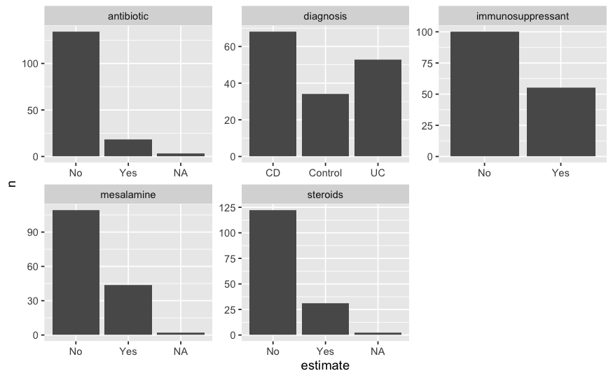

```r
eda_barplot_input <- ibd_metadata %>%
  dplyr::select(-c(taxon, sra_metagenome_name, age, fecal_calprotectin)) %>%
  tidyr::pivot_longer(cols = dplyr::everything(), names_to = "field", values_to = "estimate") %>%
  dplyr::count(field, estimate)

eda_barplot_input %>%
  ggplot2::ggplot(ggplot2::aes(estimate, n)) +
  ggplot2::geom_col() +
  ggplot2::facet_wrap(~ field, scales = "free")
```

There are two additional quantitative fields from the metadata that are worth exploring: `age` and `fecal_calprotectin`. The latter is a measure of the concentration of fecal calprotectin, a protein released by immune cells that’s used as a biomarker for active inflammation.

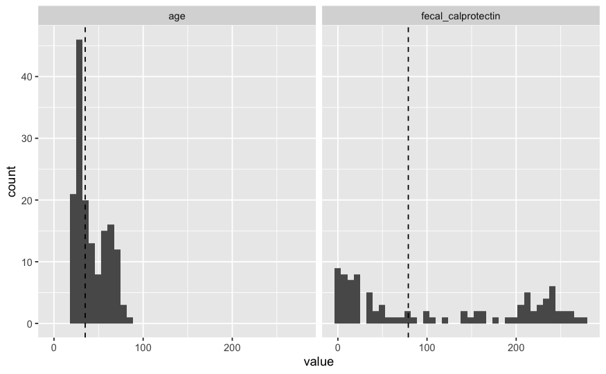

```r
ibd_metadata %>%
  dplyr::select(age, fecal_calprotectin) %>%
  tidyr::pivot_longer(cols = dplyr::everything(), names_to = "field", values_to = "value") %>%
  dplyr::filter(!is.na(value)) %>%
  dplyr::group_by(field) %>%
  dplyr::mutate(median_value = median(value, na.rm = TRUE)) %>%
  ggplot2::ggplot(ggplot2::aes(value)) +
  ggplot2::geom_histogram(bins = 40) +
  ggplot2::geom_vline(ggplot2::aes(xintercept = median_value), linetype = "dashed") +
  ggplot2::facet_wrap(~ field)
```

## Calculating richness, diversity, and evenness with simulated data

First, we’ll use the `rmultinom()` function to simulate a count matrix. We’ll use these simulated data to calculate different diversity metrics, then apply these same concepts to the IBD data.

```r
# Set seed for reproducibility
set.seed(1234)

# Simulate two matrices
simulated_mat_A <- rmultinom(
  n = 5,
  size = 100,
  prob = c(0.2, 0.4, 0.05, 0.02, 0.15, 0.13, 0.01, 0.04)
)

simulated_mat_B <- rmultinom(
  n = 5,
  size = 100,
  prob = c(0.6, 0.25, 0, 0.04, 0.02, 0.06, 0.02, 0)
)

# Bind counts from the two matrices together
sim_counts <- cbind(simulated_mat_A, simulated_mat_B)

# Add sample groups
sim_groups <- c(rep("A", 5), rep("B", 5))
```

## Reading BIOM files

We can create a `phyloseq` object using the individual tables downloaded from the separate URLs in the above section, or we can download a single `.biom` file, which contains all three in a single file. To do this, we’ll use the `biomformat` package.

```r
# Define URL
biom_url <- "https://courses.edx.org/assets/courseware/v1/93a7b509e4ea56e3e20ed64227d7b4c2/asset-v1:KULeuvenX+MICROx+3T2021+type@asset+block/ibd_data.biom"

# Read file
biom_file <- biomformat::read_biom(biom_url)

# Extract components from the biomformat object
biom_metadata <- biomformat::sample_metadata(biom_file)
lineages <- biomformat::observation_metadata(biom_file)
counts <- biomformat::biom_data(biom_file)

# Build the phyloseq object, first converting the counts and lineages to matrices
ps <- phyloseq::phyloseq(
  phyloseq::otu_table(as.matrix(counts), taxa_are_rows = TRUE),
  phyloseq::tax_table(as.matrix(lineages)),
  phyloseq::sample_data(biom_metadata)
)

# Name the fields of the taxonomy table and the metadata
colnames(phyloseq::tax_table(ps)) <- colnames(ibd_lineages[, -1])
colnames(phyloseq::sample_data(ps)) <- colnames(ibd_metadata[, -1])
```

## Visualizing counts

There were important pre-processing steps performed on the raw counts table– normalization, or rarefaction. There are several approaches to each, but in essence, the former applies a transformation to the raw abundance data such that all samples have the same total abundance; in the latter, we subsample a specified number of reads from each sample, but with some important considerations. Using rarefaction, rare taxa will be lost, as the probability of sampling reads from them is relatively low. Additionally, samples with read counts less than a minimum number specified will be discarded. Now we’ll visualize the relative abundances of each taxon at the phylum level between IBD samples and controls.

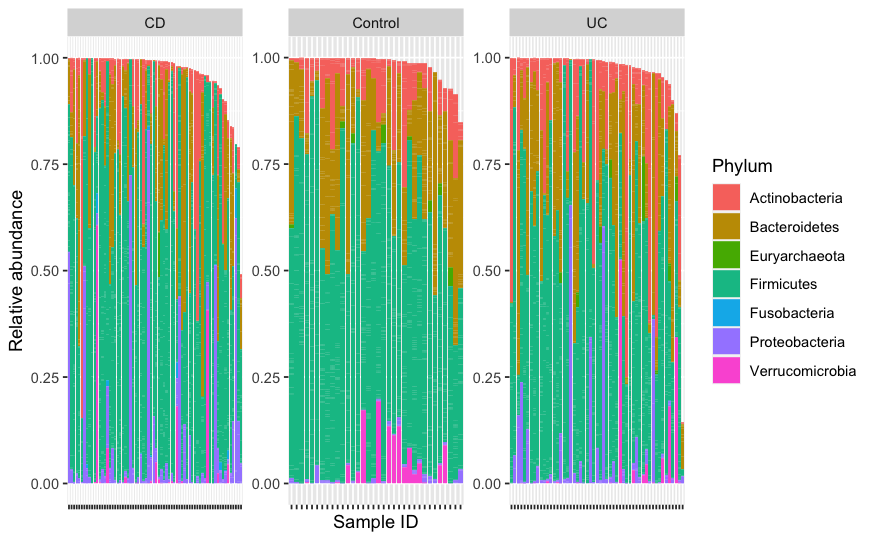

```r
# Get OTU table and metadata
relative_abundance <- data.frame(phyloseq::otu_table(ps)) %>%
  tibble::rownames_to_column("taxon") %>%
  tidyr::pivot_longer(-taxon, names_to = "sample_id", values_to = "relative_abundance")

metadata <- data.frame(phyloseq::sample_data(ps)) %>%
  tibble::rownames_to_column("sample_id")

# Join each and join with taxonomy table
phylum_barplot_input <- relative_abundance %>%
  dplyr::left_join(metadata, by = "sample_id") %>%
  dplyr::left_join(ibd_lineages, by = "taxon")

# Plot
phylum_barplot_input %>%
  ggplot2::ggplot(
    ggplot2::aes(stats::reorder(sample_id, -relative_abundance), relative_abundance, fill = phylum)
  ) +
  ggplot2::geom_col(position = "stack") +
  ggplot2::theme(axis.text.x = ggplot2::element_blank()) +
  ggplot2::facet_wrap(~ diagnosis, scales = "free") +
  ggplot2::labs(x = "Sample ID", y = "Relative abundance", fill = "Phylum")
```

There’s clearly an issue with the data set, as some of the samples have relative abundance estimates that don’t add up to 1– this could be due to the rarefaction method used. In any case, there are likely subtle patterns below the phylum level, but there do appear to be many samples in the Chron’s disease and ulcerative colitis groups that have higher relative abundance of Proteobacteria.

## Species richness

To start with analyses of diversity, richness, and evenness, we’ll use the simulated matrix count data to calculate richness. First, we’ll calculate which simulated group has more species:

```r
# Samples are in columns; species are in rows
# To find the number of species, count the number of non-zero rows in each column
toy_richness <- colSums(sim_counts != 0)
data.frame(species = toy_richness, group = sim_groups) %>%
  dplyr::group_by(group) %>%
  dplyr::summarise(num_species = sum(species))
```

| group | num_species |
| --- | --- |
| A | 39 |
| B | 27 |

We can see that group A has a greater number of observed species relative to group B. Now we’ll use the Wilcoxon test to evaluate whether or not these two estimates are statistically different, or whether the differences can be attributed to random chance.

```r
stats::wilcox.test(toy_richness ~ sim_groups)
```

```
    Wilcoxon rank sum test with continuity correction

data:  toy_richness by sim_groups
W = 25, p-value = 0.008562
alternative hypothesis: true location shift is not equal to 0
```

From this result, we can conclude that the species richness between these two groups is statistically different– more formally, the probability of seeing this difference, or greater, in species richness between groups if there was truly no difference at all is approximately 0.008.

We can also estimate the number of species using the Chao 1 estimator, which aims to estimate the true unknown number of species by taking into account the number of species that were only observed once (called singletons) or twice (called doubletons). We can calculate the Chao 1 estimator by taking the value of the number of singletons divided by twice the number of doubletons, plus the number of observed species.

```r
# Estimate number of singletons and doubletons
singletons <- colSums(sim_counts == 1)
doubletons <- colSums(sim_counts == 2)
rare_species <- singletons / (2 * doubletons)

# If there are any non numeric arguments-- e.g., Inf or NaN, change those to zero
rare_species[doubletons == 0] <- 0

# Calculate Chao 1 estimator
chao1 <- toy_richness + rare_species

# Re-calculate total number of species
data.frame(chao1_estimate = chao1, group = sim_groups) %>%
  dplyr::group_by(group) %>%
  dplyr::summarise(num_species = sum(chao1_estimate))
```

| group | num_species |
| --- | --- |
| A | 41.0 |
| B | 27.5 |

## Species evenness and diversity

One of the most popular diversity metrics, which takes into account the species richness as well as the evenness, is the Shannon diversity index. Originally described to estimate and compare entropy, the estimator is essentially weighted such that diverse communities– those with many species, all with relatively equal proportions– will have high estimates; those communities with low diversity– many species, but dominated by one or two– will have low estimates. The basic idea behind the estimate is the ability to predict the next microbe based on the identity of a randomly selected microbe from the sample– in other words, if a community is dominated by a single microbe, it’s relatively easy to predict the identity of a randomly selected microbe from the sample, thus entropy is low, and consequently so is the Shannon diversity index. In contrast, in a community with many species with relatively equal proportions, it’s rather difficult to know the identity of a randomly selected microbe from the sample, so entropy is high, and so is the Shannon diversity index.

To calculate the Shannon diversity index on the simulated data by hand, we first have to calculate the relative abundance of each species within a sample. Then, we’ll construct a function to calculate the diversity index by multiplying the relative abundance and the natural log of the relative abundance, adding up all of the non-NA entries, then multiplying that result by -1.

```r
# Calculate relative abundance
# We divide by 100 because there are 100 reads per sample
rel_abund <- apply(sim_counts, 2, function(x) x / 100)

# Construct function to estimate Shannon diversity index
shannon_diversities <- apply(rel_abund, 2, function(x) {
  x <- x * log(x)
  x_sum <- -1 * (sum(na.omit(x))) # add everything in the vector, ommitting the NA entries
  return(x_sum)
})

# Now perform the Wilcoxon test
round(stats::wilcox.test(shannon_diversities ~ sim_groups)$p.value, 3)
```

```
[1] 0.008
```

Next, we can calculate Pielou’s evenness index. This index takes the Shannon diversity index for each sample divided by the maximum Shannon diversity index for a given sample, which is the natural log times the number of species. Samples where the species abundances are similar have high Pielou’s index estimates; those with dramatically different abundances have low estimates.

```r
# Calculate the max Shannon diversity per sample
max_shannon <- log(toy_richness)

# Calculate Pielou's evenness
pielous_evenness <- shannon_diversities / max_shannon

# Wicoxon test
stats::wilcox.test(pielous_evenness ~ sim_groups) # same p-value, since the test looks at ranks
```

```
    Wilcoxon rank sum exact test

data:  pielous_evenness by sim_groups
W = 25, p-value = 0.007937
alternative hypothesis: true location shift is not equal to 0
```

Finally, we can calculate the inverse Simpson index, which is just the sum of all of the relative abundance estimates squared, for each sample (which are in columns). We’ll calculate the inverse, as it’s easier to interpret.

```r
# Using simulated data
inverse_simpson <- 1 / colSums(rel_abund^2)

# Answering question from the course
sim_vec <- c(0.4, 0.2, 0.3, 0.1)
1 / sum(sim_vec ^ 2) # 3.3333
```

```
[1] 3.333333
```

```r
# question 4
species_counts <- c(4, 10, 2)
relative_abundance <- species_counts / sum(species_counts)
x <- relative_abundance * log(relative_abundance)
round(-1 * sum(x), 4)
```

```
[1] 0.9003
```

```r
# question 5-- inverse Simpson index
prop_abundance <- rep(0.25, 4) # all with proportional abundance 0.25
1 / sum(prop_abundance ^ 2) # 4
```

```
[1] 4
```

## Diversity

We can compare the diversity between groups to ask several important questions that are directly testable as hypotheses: 1) are there differences in the diversity of microbial communities between groups; 2) are there differences in the species evenness of the microbial communities between groups; and 3) are there differences in diversity indices between groups? We can directly test these by looking at the species richness, diversity indices above (e.g., Shannon’s diversity index and inverse Simpson’s diversity index), and species evenness (e.g., Pielou’s evenness index) using different fields in the metadata. As an example below, we’ll just look at the differences based on diagnosis.

```r
# Turn taxa relative abundances into matrix
tax_mat <- as.matrix(ibd_taxa[, -1])

# Calculate observed richness
obs_richness <- apply(tax_mat, 2, function(x) length(x[x != 0]))

# Calculate Shannon diversity
shannon <- apply(tax_mat, 2, function(x) {
  x <- x * log(x)
  sum_x <- -1 * sum(na.omit(x))
  return(sum_x)
})

# Calculate Pielou
max_shannon <- log(obs_richness)
pielou <- shannon / max_shannon

# Calculate inverse Simpson
inv_simpson <- 1 / colSums(tax_mat ^ 2)

# Match taxon field in metadata with taxa table
ibd_metadata$taxon <- stringr::str_to_lower(gsub("\\.", "_", ibd_metadata$taxon))

# Bind results into a single data frame
# Modify so that the diagnosis is exactly two levels
df <- cbind(obs_richness, shannon, pielou, inv_simpson) %>%
  data.frame() %>%
  tibble::rownames_to_column("taxon") %>%
  dplyr::left_join(ibd_metadata, by = "taxon") %>%
  dplyr::mutate(diagnosis = ifelse(diagnosis == "UC" | diagnosis == "CD", "IBD", "control"))

# Create nested data frame
nested_df <- df %>%
  tidyr::pivot_longer(
    cols = c("obs_richness", "shannon", "pielou", "inv_simpson"),
    names_to = "metric",
    values_to = "value") %>%
  dplyr::group_by(metric) %>%
  tidyr::nest()

nested_results <- nested_df %>%
  dplyr::mutate(
    wilcox = purrr::map(data, ~ stats::wilcox.test(value ~ diagnosis, data = .x)),
    pval = purrr::map_dbl(wilcox, ~ .x %>% purrr::pluck("p.value"))
  )

nested_results %>%
  dplyr::select(metric, pval)
```

[output not shown]

From these results, we can see that there is a difference in all of the above richness, evenness, and diversity indices between the IBD and control groups. Below we’ll create a series of boxplots to visualize the differences.

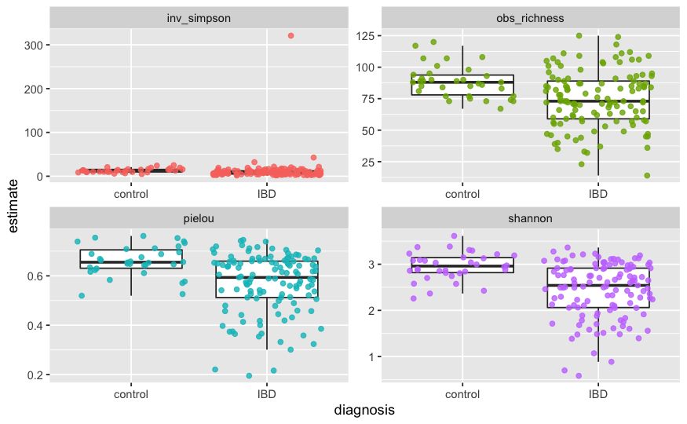

```r
df %>%
  tidyr::pivot_longer(
    cols = c("obs_richness", "shannon", "pielou", "inv_simpson"),
    names_to = "metric",
    values_to = "estimate"
  ) %>%
  ggplot2::ggplot(ggplot2::aes(diagnosis, estimate)) +
  ggplot2::geom_boxplot(outlier.shape = NA) +
  ggplot2::geom_jitter(ggplot2::aes(color = metric), alpha = 0.8) +
  ggplot2::facet_wrap(~metric, scales = "free") +
  ggplot2::theme(legend.position = "none")
```

From this series of plots, we can see that in general, patients with IBD have lower species richness and diversity (measured by the Shannon diversity index) relative to controls. Additionally, the species evenness is lower in patients with IBD relative to controls. Instead of comparing just two groups (i.e., IBD vs controls), we can compare multiple groups using the Kruskal-Wallis test. We’ll use the same nested data frame approach, except leave the diagnoses as they are without modification.

```r
kw_df <- cbind(obs_richness, shannon, pielou, inv_simpson) %>%
  data.frame() %>%
  tibble::rownames_to_column("taxon") %>%
  dplyr::left_join(ibd_metadata, by = "taxon")

# Build nested data frame and run kruskal-wallis test
nested_kw <- kw_df %>%
  tidyr::pivot_longer(
    cols = c("obs_richness", "shannon", "pielou", "inv_simpson"),
    names_to = "metric",
    values_to = "value") %>%
  dplyr::group_by(metric) %>%
  tidyr::nest()

# Perform test
nested_kw %>%
  dplyr::mutate(kw_test = purrr::map(data, ~ stats::kruskal.test(value ~ diagnosis, data = .x)),
                chi_stat = purrr::map_dbl(kw_test, ~ .x %>% purrr::pluck("statistic")),
                pval = purrr::map_dbl(kw_test, ~ .x %>% purrr::pluck("p.value")))
```

| metric | data | kw_test | chi_stat | pval |
| --- | --- | --- | --- | --- |
| obs_richness |  |  | 13.14342 | 1.399403e-03 |
| shannon |  |  | 25.01088 | 3.706431e-06 |
| pielou |  |  | 22.95719 | 1.034924e-05 |
| inv_simpson |  |  | 16.60676 | 2.476778e-04 |

Indeed, all of these p-values are also statistically significant– with the Kruskal-Wallis test, the alternative hypothesis is that at least one of location parameters for the distribution of the value of the metrics is different than the others. We can also use a pairwise Wilcoxon rank-sum test and apply a multiple testing correction using the same Kruskal-Wallis nested data frame.

```r
# Pull out the value and diagnosis vectors, then use broom::tidy() to compile the results
pairwise_wilcox_results <- nested_kw %>%
  dplyr::mutate(
    value = purrr::map(data, ~ .x %>% dplyr::pull("value")),
    diagnosis = purrr::map(data, ~ .x %>% dplyr::pull("diagnosis")),
    pairwise_wilcox = purrr::map2(value, diagnosis, ~ stats::pairwise.wilcox.test(.x, .y)),
    tidy_results = purrr::map(pairwise_wilcox, ~ broom::tidy(.x))
  )

# Unnest and identify statistically significant results
unnest_pairwise_results <- pairwise_wilcox_results %>%
  dplyr::select(metric, tidy_results) %>%
  unnest(cols = c("tidy_results"))

# Look at Shannon diversity specifically
unnest_pairwise_results[unnest_pairwise_results$metric == "shannon", ]
```

| metric | group1 | group2 | p.value |
| --- | --- | --- | --- |
| shannon | Control | CD | 2.955996e-06 |
| shannon | UC | CD | 7.875818e-02 |
| shannon | UC | Control | 1.088916e-03 |

We can see from the table above that just looking at the Shannon diversity index using the pairwise Wilcoxon rank-sum test, only the comparisons between control and Chron’s disease and control and ulceritive colitis are statistically significant; the comparison between Chron’s disease and ulceritive colitis is not statistically significant.

```r
dplyr::filter(unnest_pairwise_results, p.value < 0.05)
```

| metric | group1 | group2 | p.value |
| --- | --- | --- | --- |
| obs_richness | Control | CD | 2.600180e-03 |
| obs_richness | UC | Control | 2.807666e-03 |
| shannon | Control | CD | 2.955996e-06 |
| shannon | UC | Control | 1.088916e-03 |
| pielou | Control | CD | 5.051910e-06 |
| pielou | UC | CD | 2.876788e-02 |
| pielou | UC | Control | 2.876788e-02 |
| inv_simpson | Control | CD | 1.899385e-04 |
| inv_simpson | UC | Control | 9.015913e-03 |

In fact, the only comparison where the is a statistically significant difference between both disease groups is the Pielou evenness index. Now that we know there’s a statistically significant difference in the location parameteres of the Shannon diversity with diagnosis, we can look at metadata including antibiotic, immunosuppressant, mesalamine, and steroid usage.

```r
ibd_metadata %>%
  tidyr::pivot_longer(cols = c("antibiotic", "immunosuppressant", "mesalamine", "steroids"),
                      names_to = "therapy",
                      values_to = "status") %>%
  dplyr::group_by(therapy) %>%
  tidyr::nest() %>%
  dplyr::mutate(
    kw_test = purrr::map(data, ~ stats::kruskal.test(shannon, .x$status)),
    pvals = purrr::map_dbl(kw_test, ~ .x %>% purrr::pluck("p.value"))
  )
```

| therapy | data | kw_test | pvals |
| --- | --- | --- | --- |
| antibiotic |  |  | 0.0014920446 |
| immunosuppressant |  |  | 0.0599565022 |
| mesalamine |  |  | 0.7532157494 |
| steroids |  |  | 0.0007696888 |

From the hypothesis testing of multiple metadata fields with the Kruskal-Wallis test, we can see that only antibiotic and steroid use are statistically significant between the different groups (more formally, at least one of the location parameters is different). Next, we can look at the Shannon diversity as a function of quantitative variables in the metadata– age and fecal calprotectin concentration. First, we’ll create scatterplots for each.

```
Warning: Removed 62 rows containing non-finite values (stat_smooth).
Warning: Removed 62 rows containing missing values (geom_point).
```

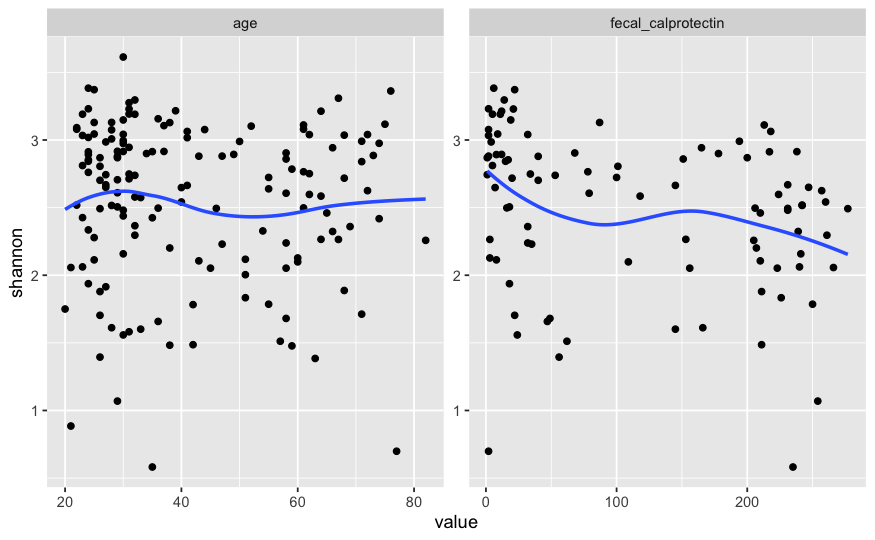

```r
plot_input <- kw_df %>%
  dplyr::select(taxon, shannon, age, fecal_calprotectin) %>%
  tidyr::pivot_longer(
    cols = c("age", "fecal_calprotectin"),
    names_to = "field",
    values_to = "value"
  )

plot_input %>%
  ggplot2::ggplot(ggplot2::aes(value, shannon)) +
  ggplot2::geom_point() +
  ggplot2::geom_smooth(se = FALSE) +
  ggplot2::facet_wrap(~ field, scales = "free")
```

```r
plot_input %>%
  dplyr::group_by(field) %>%
  tidyr::nest() %>%
  dplyr::mutate(mod = purrr::map(data, ~ lm(shannon ~ value, data = .x)),
                mod_res = purrr::map(mod, ~ broom::tidy(.x)),
                pval = purrr::map_dbl(mod_res, ~ dplyr::pull(.x, "p.value")[2])) # grab p-value for beta1, not intercept
```

| field | data | mod | mod_res | pval |
| --- | --- | --- | --- | --- |
| age |  |  |  | 0.444741961 |
| fecal_calprotectin |  |  |  | 0.008652371 |

Using a simple linear regression, there is no statistically significant association between age and Shannon diversity, but there is a significant relationship between fecal calprotectin concentration and Shannon diversity. We’ll skip the formal regression diagnostics for now, and instead use a correlation test as another way to explore the relationship between Shannon diversity and these two quantitative metadata fields. The `cor.test()` function has several options to use for the correlation metrics– we’ll use the Spearman’s method here, which will calculate the rho statistic as a rank-based measure of association (that is, without making distributional assumptions, similar to the Wilcoxon and Kruskal-Wallis rank-sum tests).

```r
cor.test(kw_df$shannon, kw_df$age, method = "spearman") # p-value = 0.3699
```

```
    Spearman's rank correlation rho

data:  kw_df$shannon and kw_df$age
S = 665621, p-value = 0.3699
alternative hypothesis: true rho is not equal to 0
sample estimates:
        rho
-0.07250963
```

```r
cor.test(kw_df$shannon, kw_df$fecal_calprotectin, method = "spearman") # p-value = 0.0002
```

```
    Spearman's rank correlation rho

data:  kw_df$shannon and kw_df$fecal_calprotectin
S = 183371, p-value = 0.0002845
alternative hypothesis: true rho is not equal to 0
sample estimates:
       rho
-0.3679938
```

In addition to comparing the diversity and evenness indices for all taxa combined, we can use the Wilcoxon rank-sum test to look at the difference between the distributions of individual taxa.

```r
ind_nested_df <- ibd_taxa %>%
  tidyr::pivot_longer(-taxon, names_to = "sample_id", values_to = "relative_abundance") %>%
  dplyr::left_join(ibd_metadata, by = c("sample_id" = "taxon")) %>%
  dplyr::group_by(taxon) %>%
  tidyr::nest()

# Perform Kruskal-Wallis test -- we have three diagnoses
ind_results <- ind_nested_df %>%
  dplyr::mutate(
    kw = purrr::map(data,  ~ stats::kruskal.test(relative_abundance ~ diagnosis, data = .x)),
    pval = purrr::map_dbl(kw, ~ purrr::pluck(.x, "p.value"))
  )

# Correct for multiple testing and filter significant taxa
ind_padj <- ind_results %>%
  dplyr::select(taxon, pval) %>%
  dplyr::ungroup() %>%
  dplyr::mutate(padj = stats::p.adjust(pval, method = "BH")) %>%
  dplyr::filter(padj < 0.05)
```

There are 87/201 taxa that have different distributions in at least one of the diagnoses using the Krusal-Wallis test and an adjusted p-value of 0.05. Since there are so many, we can’t look at the differences in counts between both– instead, let’s sort the results by adjusted p-value and pick the three taxa with the lowest p-values.

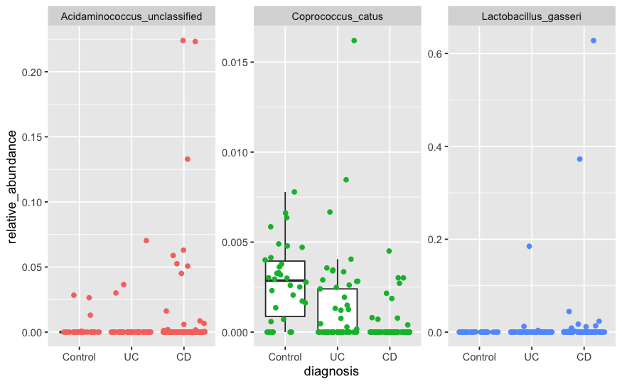

```r
top3_taxa <- ind_padj %>%
  dplyr::arrange(padj) %>%
  dplyr::slice_head(n = 3) %>%
  dplyr::pull("taxon")

ind_nested_df %>%
  dplyr::filter(taxon %in% top3_taxa) %>%
  tidyr::unnest(cols = c("data")) %>%
  dplyr::mutate(diagnosis = factor(diagnosis, levels = c("Control", "UC", "CD"))) %>% # control factor levels for plotting
  ggplot2::ggplot(ggplot2::aes(diagnosis, relative_abundance)) +
  ggplot2::geom_boxplot(outlier.shape = NA) +
  ggplot2::geom_jitter(ggplot2::aes(color = taxon)) +
  ggplot2::facet_wrap(~ taxon, scales = "free") +
  ggplot2::theme(legend.position = "none")
```

## Ordination

There are several ways to measure beta-diversity, or the comparison of communities between samples. Some of the most popular metrics are the Jaccard index, the Bray-Curtis dissimilarity, and the UniFrac distance. Each method takes a slightly different approach and uses different information in the evaluation of beta-diversity to compare communities. For example, the Jaccard index only takes into account the number of species that are shared between two communities relative to the total number of species in both communities, without taking abundance into account. The Bray-Curtis dissimilarity can be thought of as a natural extension to the Jaccard index, as it takes into account the abundance of each taxon in each community being compared. Finally, the UniFrac distance uses a different approach altogether, this time using phylogenetic information. Specifically, it uses the sum of the unshared branch lengths divided by the sum of all branch lengths. There are two general flavors of UniFrac distance– the unweighted estimate (the one just described), and the weighted estimate, which takes into account taxonomic abundance. We can use ordination to reduce dimensionality and plot the dissimilarities between communities in a 2-dimensional space. Each axis in the 2-dimensional plot corresponds to the proportion of variance explained along an orthogonal axis in the dissimilarity matrix. Qualitative metadata can be used to annotate the plots to understand how samples cluster in 2-dimensional space by disease status, origin, etc. Additionally, vectors can be draw to show associations between ordination axes and taxa. To start, we’ll calculate the Jaccard distance manually for an example data set.

```r
# Define test example
jaccard_ex <- data.frame(
  species = 1:8,
  sample1 = c(25, 37, 4, 3, 16, 15, 0, 0),
  sample2 = c(23, 39, 4, 0, 14, 13, 1, 6)
)

# Get the species IDs with counts > 0 for each sample
set_a <- jaccard_ex[jaccard_ex$sample1 != 0, 1]
set_b <- jaccard_ex[jaccard_ex$sample2 != 0, 1]

# Intersection divided by the union of the species
numerator <- length(dplyr::intersect(set_a, set_b)) # 5
denominator <- length(dplyr::union(set_a, set_b)) # 8

# Calculate Jaccard distance
jaccard_manual <- 1 - (numerator / denominator) # 0.375

# Answering another question in the course
set_a <- jaccard_ex[jaccard_ex$sample1 != 0, 1]
set_b <- which(c(20, 15, 0, 11, 12, 16, 18, 0) != 0) # all taxa except 3 and 8
numerator <- length(dplyr::intersect(set_a, set_b))
denominator <- length(dplyr::union(set_a, set_b))
round(1 - (numerator / denominator), 3) # 0.286
```

```
[1] 0.286
```

```r
x <- sum(abs(jaccard_ex$sample2 - jaccard_ex$sample1))
y <- sum(jaccard_ex$sample1, jaccard_ex$sample2)
1 - (x / y) # 0.91
```

```
[1] 0.91
```

In cases where there are many taxa, some of which may be very similar to one another, incorporating phylogenetic information may be important. In these instances, the UniFrac distance is a good choice for dissimilarity metric. Next, we can use the `vegan` package to perform the ordinations. We’ll use principal coordinates analysis, which takes a distance or dissimilarity matrix, performs the eigenvalue decomposition, and returns the eigenvectors and eigenvalues. First we’ll use the simulated matrix.

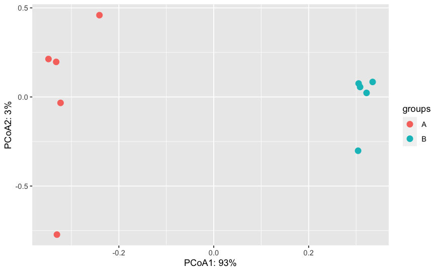

```r
# Perform the ordination with PCoA on the Bray-Curtis dissimilarity
pcoa_res <- vegan::capscale(
  formula = t(sim_counts) ~ 1,
  distance = "bray",
  na.action = "na.omit"
)

# Extract eigenvalues
sim_eigenvals <- vegan::eigenvals(pcoa_res)

# Get the percentage of variation explained by each eigenvalue
perc_var <- round(sim_eigenvals / sum(sim_eigenvals) * 100)

# Extract dimensions, add group information, and plot
data.frame(pcoa_res$CA$u) %>%
  dplyr::mutate(groups = sim_groups) %>%
  ggplot2::ggplot(ggplot2::aes(MDS1, MDS2, color = groups)) +
  ggplot2::geom_point(size = 3) +
  ggplot2::labs(
    x = paste0("PCoA1: ", perc_var[1], "%"),
    y = paste0("PCoA2: ", perc_var[2], "%")
  )
```

We can also use non-metric multidimensional scaling (nMDS) to reduce dimensionality. The major difference between PCoA and nMDS is that the former uses a transformation and eigenvalue decomposition to retain all variation, while the latter applies a transformation to the data to such that it fits in a specified smaller number of dimensions. Various cost functions are utilized to iteratively transform the data and evaluate the fit relative to the untransformed data. We can use the stress cost function implemented in `vegan::metaMDS()` to perform the nMDS and specify that we want to transform the data such that it fits in 2-dimensional space.

```r
sim_nmds <- vegan::metaMDS(
  comm = t(sim_counts),
  distance = "bray",
  k = 2)
```

```
Square root transformation
Wisconsin double standardization
*** No convergence -- monoMDS stopping criteria:
     3: no. of iterations >= maxit
    17: stress < smin
```

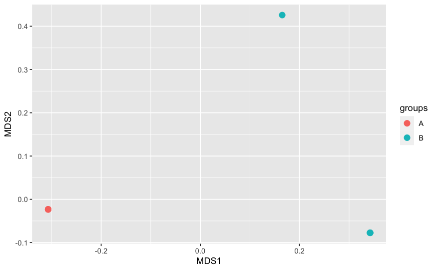

```r
sample_scores <- data.frame(sim_nmds$points) %>%
  tibble::rownames_to_column("sample_id") %>%
  dplyr::mutate(groups = sim_groups)

sample_scores %>%
  ggplot2::ggplot(ggplot2::aes(MDS1, MDS2, label = sample_id)) +
  ggplot2::geom_jitter(ggplot2::aes(color = groups), size = 3) +
  ggrepel::geom_label_repel()
```

Because of the nMDS technique and the simulated data we’re using, almost all of the points are essentially plotted on top of one another. We can see which species contribute to clustering in the ordinations using the `vegan::scores()` function.

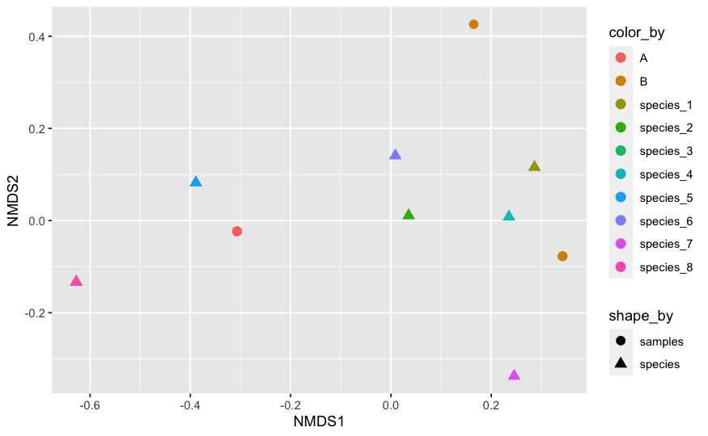

```r
# Extract species scores
species_scores <- data.frame(vegan::scores(sim_nmds, display = "species")) %>%
  tibble::rownames_to_column("id") %>%
  dplyr::mutate(id = paste0("species_", id))

# Bind with sample scores above
plot_input <- sample_scores %>%
  dplyr::rename(
    "id" = "sample_id",
    "NMDS1" = "MDS1",
    "NMDS2" = "MDS2"
  ) %>%
  dplyr::select(-groups) %>%
  dplyr::bind_rows(species_scores) %>%
  dplyr::mutate(color_by = c(rep("A", 5), rep("B", 5), paste0("species_", 1:8)),
                shape_by = c(rep("samples", 10), rep("species", 8)))

# Plot
plot_input %>%
  ggplot2::ggplot(ggplot2::aes(NMDS1, NMDS2)) +
  ggplot2::geom_point(aes(color = color_by, shape = shape_by), size = 3) +
  ggrepel::geom_label_repel(ggplot2::aes(label = id), max.overlaps = Inf)
```

```r
NA
```

Now that we’ve built these plots using the simulated data, we’ll use the same approaches to apply ordinations to the IBD data.

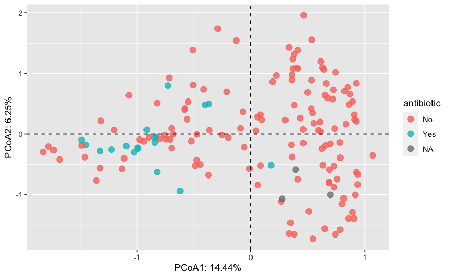

```r
# Perform PCoA on the IBD data-- note, remove the first column with the taxa IDs
pcoa_ibd <- vegan::capscale(
  formula = t(ibd_taxa[, -1]) ~ 1,
  distance = "bray",
  na.action = "na.omit"
  )

# Get the eigenvalues
eigs <- vegan::eigenvals(pcoa_ibd)

# Get the percentage of variance contained in each eigenvector
perc_eigs <- round(eigs / sum(eigs) * 100, 2)

# Get individual coordinates and bind with metadata
ind_coords <- data.frame(vegan::scores(pcoa_ibd, display = "sites")) %>%
  tibble::rownames_to_column("sample_id") %>%
  dplyr::left_join(ibd_metadata, by = c("sample_id" = "taxon"))

# Plot and color by diagnosis
ibd_pcoa_plot <- ind_coords %>%
  ggplot2::ggplot(ggplot2::aes(MDS1, MDS2, color = antibiotic)) +
  ggplot2::geom_point(size = 3, alpha = 0.8) +
  ggplot2::geom_vline(xintercept = 0, linetype = "dashed") +
  ggplot2::geom_hline(yintercept = 0, linetype = "dashed") +
  ggplot2::labs(
    x = paste0("PCoA1: ", perc_eigs[1], "%"),
    y = paste0("PCoA2: ", perc_eigs[2], "%")
  )

ibd_pcoa_plot
```

Although we can look at many other metadata variables, this is a good example of relatively clear separation in community composition between groups that received antibiotics vs those that did not. It is worth noting, however, that there is some overlap, meaning that in some patients, there is some similarity between microbial communities regardless of antibiotic status. Next, we’ll apply nMDS to the same data.

```r
# Perform the ordination
nmds_ibd <- vegan::metaMDS(
  comm = t(ibd_taxa[, -1]),
  distance = "bray",
  k = 2,
  trymax = 100
)
```

```
*** No convergence -- monoMDS stopping criteria:
    23: no. of iterations >= maxit
    77: stress ratio > sratmax
```

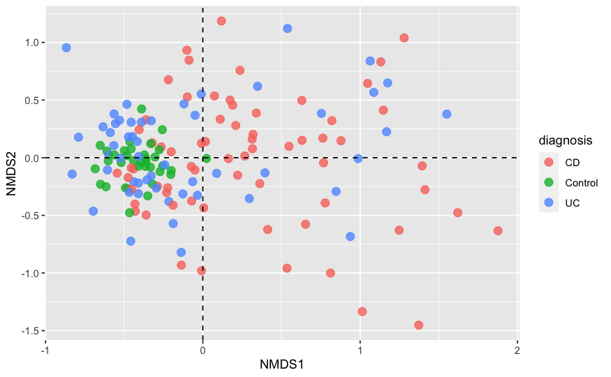

```r
# Get scores and bind with metadata
data.frame(vegan::scores(nmds_ibd, display = "sites")) %>%
  tibble::rownames_to_column("sample_id") %>%
  dplyr::left_join(ibd_metadata, by = c("sample_id" = "taxon")) %>%
  ggplot2::ggplot(ggplot2::aes(NMDS1, NMDS2, color = diagnosis)) +
  ggplot2::geom_point(size = 3, alpha = 0.8) +
  ggplot2::geom_vline(xintercept = 0, linetype = "dashed") +
  ggplot2::geom_hline(yintercept = 0, linetype = "dashed")
```

[output not shown]

Using this code, we can see that in order to get a good fit, we need to fit 7 dimensions. In the course, their analysis showed that 8 dimensions were needed to obtain stress values < 0.1, and they also ask which combination of the 8 nMDS dimensions shows separation between the healthy and IBD individuals. To do this, we’ll build a function to plot the nMDS ordination, then iterate over successive combinations of dimensions (e.g., nMDS dimension 1 vs. 2; 2 vs. 3; 4 vs. 5, etc).

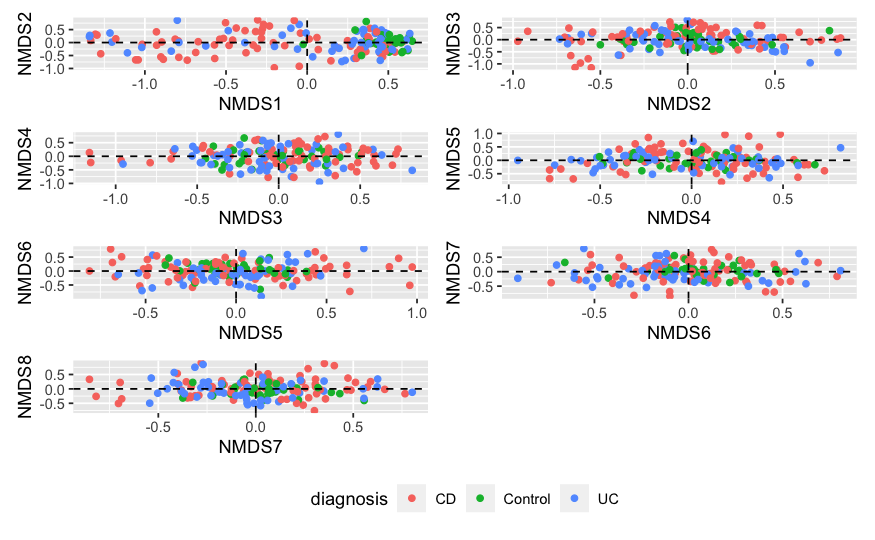

From the plots above, we really only see the separation of healthy and IBD patients using the first two dimensions. It’s important to note that the stress value for just these two dimensions is higher than the stress value for all eight dimensions, but it doesn’t look like the variation explained by the higher dimensions does much to separate samples based on diagnosis. To identify which metadata fields are correlated with different ordination dimensions, we can either create figures or use a more formal, automated approach using the `vegan::evnfit()` function. The basic idea is that metadata associated with a particular clustering pattern will be correlated with the principal components in the ordination. We can use a permutation test to evaluate the statistical significance of the correlations, such that we only interpret the meaningful associations.

First, we’ll use this approach on the simulated data.

```r
# Push metadata groups into a data frame
metadata_groups <- data.frame(groups = sim_groups)

# Perform the environmental associations
sim_envfit <- vegan::envfit(ord = pcoa_res, env = metadata_groups, perm = 1000, choices = c(1, 2), na.rm = TRUE)
sim_envfit
```

```
***FACTORS:

Centroids:
           MDS1    MDS2
groupsA -0.4735  0.0190
groupsB  0.4735 -0.0190

Goodness of fit:
           r2  Pr(>r)
groups 0.4969 0.01199 *
---
Signif. codes:  0 ‘***’ 0.001 ‘**’ 0.01 ‘*’ 0.05 ‘.’ 0.1 ‘ ’ 1
Permutation: free
Number of permutations: 1000
```

There is a lot of information in this summary output. First, the goodness of fit element describes how well the fitted centroids of the different groups on each ordination dimension fit the data, as measured by r^2. Second, we can see that this association is statistically significant using the permutation test. Now let’s use this same approach with the IBD data.

```r
env_metadata <- ibd_metadata %>%
  dplyr::select(-c(taxon, sra_metagenome_name)) %>%
  dplyr::mutate(dplyr::across(.cols = c("age", "fecal_calprotectin"), ~ as.numeric(.x)))

ibd_envfit <- vegan::envfit(
  ord = pcoa_ibd,
  env = env_metadata,
  perm = 1000,
  choices = c(1, 2),
  na.rm = TRUE
)

# Look at the quantitative variable
ibd_envfit$vectors # only fecal calprotectin concentration is significant
```

```
                       MDS1     MDS2     r2   Pr(>r)
age                -0.65731  0.75362 0.0126 0.565435
fecal_calprotectin -0.94244 -0.33437 0.1927 0.000999 ***
---
Signif. codes:  0 ‘***’ 0.001 ‘**’ 0.01 ‘*’ 0.05 ‘.’ 0.1 ‘ ’ 1
Permutation: free
Number of permutations: 1000
```

```r
# Look at the qualitative variables
ibd_envfit$factors$pvals # everything except mesalamine is significant
```

```
        diagnosis        antibiotic immunosuppressant        mesalamine          steroids
      0.000999001       0.000999001       0.000999001       0.085914086       0.004995005
```

The resulting permutation test suggests that the diagnosis and antibiotic, immunosuppressant, and steroid status are all significantly correlated with the ordination dimensions. Additionally, fecal calprotectin concentration is significantly associated with the ordination, while age is not. To find which of the signficant variables are most strongly correlated with community variation, we can extract both the correlation estimate and p-value for each, then do some filtering.

| variable | correlations | pvals |
| --- | --- | --- |
| diagnosis | 0.20445450 | 0.000999001 |
| fecal_calprotectin | 0.19274726 | 0.000999001 |
| antibiotic | 0.10124268 | 0.000999001 |
| immunosuppressant | 0.08730697 | 0.000999001 |
| steroids | 0.05519269 | 0.004995005 |

Overall, the variable most strongly correlated with community variation is diagnosis. We can extract the centroids from this object and plot them on top of the PCoA plot for the IBD data.

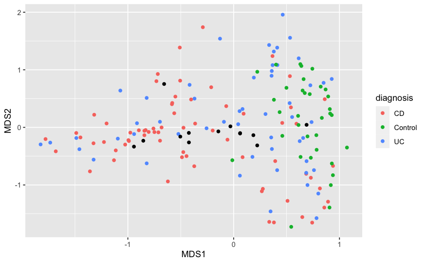

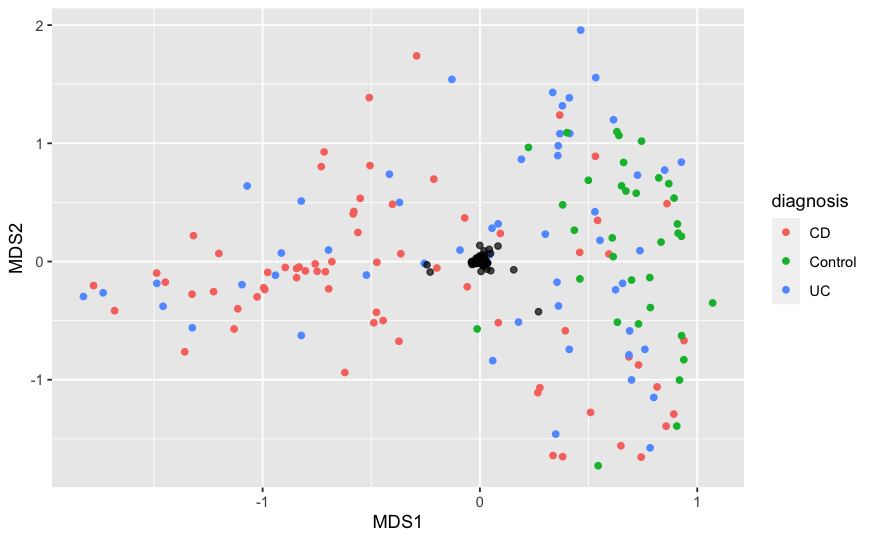

```r
# Generate base PCoA plot and overlay species
ggplot2::ggplot() +
  ggplot2::geom_point(ggplot2::aes(MDS1, MDS2, color = diagnosis), data = ind_coords) +
  ggplot2::geom_point(ggplot2::aes(X1, X2), color = "black", alpha = 0.7, data = species_input) +
  ggrepel::geom_label_repel(ggplot2::aes(X1, X2, label = label_if), data = species_input, max.overlaps = Inf,
                            nudge_x = rep(c(-0.5, 0.5), 2), nudge_y = rep(c(-0.5, 0.5), 2))
```